## Domain

Our domain of interest is social media. We’re interested in this domain because social media consumption behaviors could help us understand what makes people follow certain social media pages or trends more over the others. This information could help future creators and marketers strategize better ideas and plans during the content creation process. We hope to uncover what elements of a social media page lead to more engagement, what trends are more likely to be popular, and how social media usage varies amongst different groups.

## Data

We found the data set we used, Social Influence on Shopping, on a site called data.world. This data was collected by a team led by Adam Halper using their social survey mobile platform Whatsgoodly. They have over 300,000 millenial and Gen Z members and garnered over 150 million survey responses from this demographic to date. This data contains 1450 observations and 6 features.

## Summary Information

The dataset collected information on which social media platform influenced people’s online shopping the most. In our summary information script, we made a list of how many people felt most influenced by each social media platform.

```
## $num_features
## [1] 6
##
## $num_socials
## [1] 5
##
## $num_facebook
## [1] 10329
##
## $num_instagram
## [1] 16524
##
## $num_snapchat
## [1] 1574
##
## $num_twitter
## [1] 3407
##
## $num_none
## [1] 18936
```

This summary shows that Instagram and Facebook are the most influential in a person’s online shopping. However, more people said none of the social media platforms had the most influence.

## Aggregate Table

| answer | total_count | percentage |
| --- | --- | --- |
| Facebook | 486 | 22 |
| Instagram | 729 | 34 |
| None | 761 | 35 |
| Snapchat | 68 | 3 |
| Twitter | 131 | 6 |

This table shows the total count and percentage of each answer among University students. We see here that it follows the same pattern of none, Instagram, and Facebook being the most popular answers.

## Chart 1

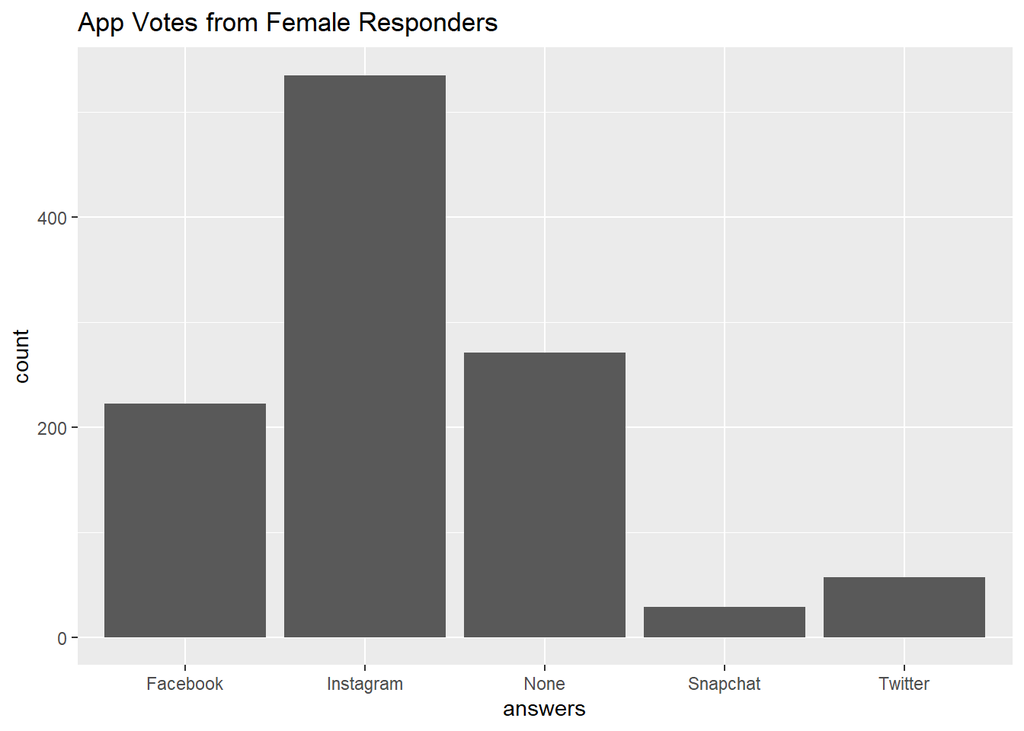

This bar graph investigates how female responders answered this survery. The proportion of those who picked Instagram is much higher among only females than the whole sample.

## Chart 2

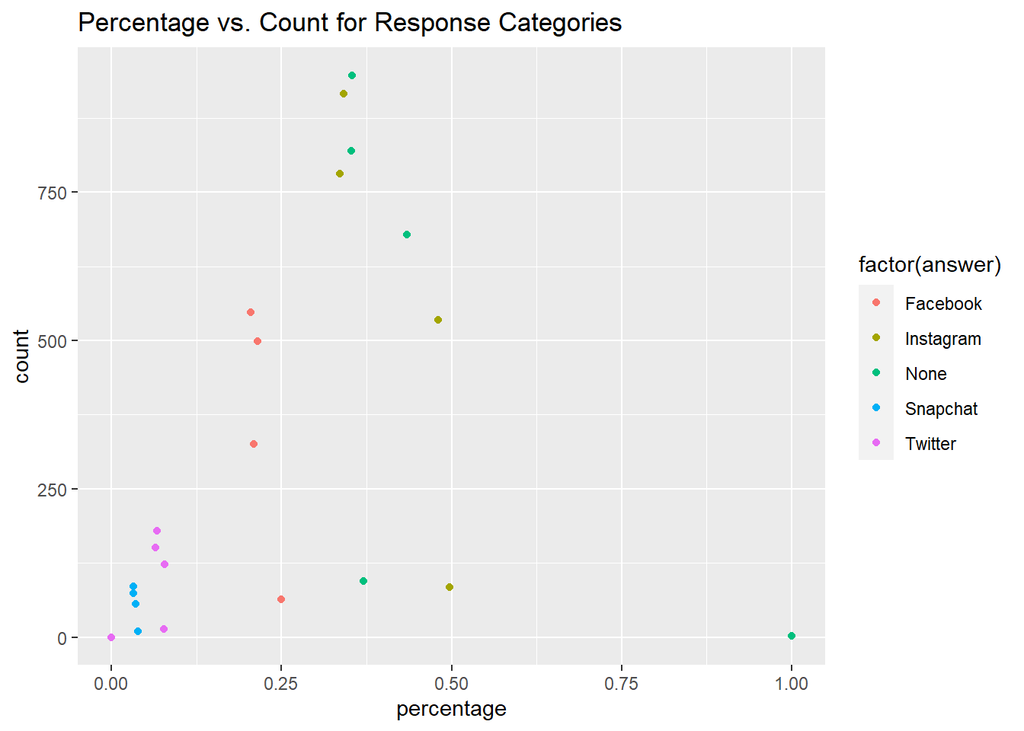

## Chart 3

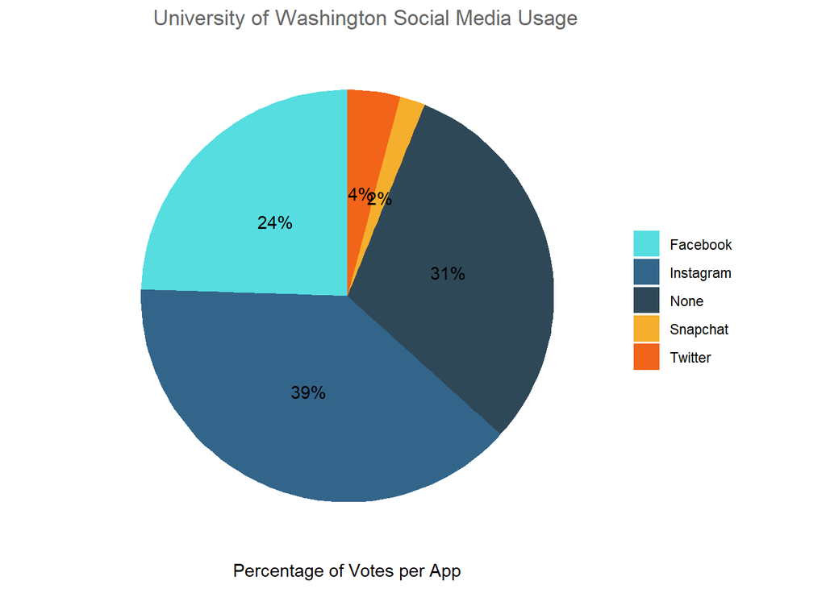

This pie chart shows the percentage of votes per app among UW students. Very few UW students voted for Snapchat and Twitter, while most of the votes were for none, Instagram, and Facebook.